# Project 1

William Miller

## Background

A survey was conducted asking a random sample of 64 people a series of questions regarding different aspects of their lives. This data was then collected and is presented in the below table. The categories for which they were questioned included biological sex, relationship status, hours spent on social media, hours spent sleeping each night, grades received in their classes, and over all happiness. From the dataset the following question was proposed. Does the grade someone receives in their classes change depending upon their relationship status? How does that change with gender?

```r
datatable(data.set1, options = list(pageLength = 8, dom = 'tip'), colnames = c("Biological Sex", "Relationship Status", "Avg Time on Social Media", "Avg Sleep Each Night", "Avg Grade in Classes", "Overal Life Satisfaction"), rownames = FALSE, class = 'cell-border stripe', caption = "Dataset: Sample Social Infromation" )
```

| Biological Sex | Relationship Status | Avg Time on Social Media | Avg Sleep Each Night | Avg Grade in Classes | Overal Life Satisfaction |
| --- | --- | --- | --- | --- | --- |
| Male | In a Relationship | 1 | 7.5 | 4 | 5 |
| Female | Single | 1 | 8 | 4 | 5 |
| Female | In a Relationship | 1 | 7 | 5 | 5 |
| Male | In a Relationship | 2.5 | 6 | 4 | 4 |
| Male | Single | 2 | 7 | 4 | 4 |
| Female | Single | 5 | 6 | 3 | 4 |
| Female | Single | 4 | 8 | 4 | 4 |
| Female | In a Relationship | 5 | 6 | 4 | 4 |
| Female | Married | 2 | 5 | 4 | 4 |
| Female | Married | 5 | 7 | 4 | 4 |

[output cut: 54 more lines]

## Analysis

The data will be split into multiple groups, one based on gender, and then the other based on relationship status (Single and In a Relationship/Married). The First part of the analysis will analyse grades based on relationship status for males, and then the next will analyse grades based on relationship status females. The following hypothesis will be used for both parts, to answer the question whether relationship status effects grades, and how that changes with gender.

**Hypothesis**

$$H_0: \text{Difference in the Medians} = 0$$
$$H_a: \text{Difference in the Medians} \neq 0$$
$$\text{Level of Significance}: \alpha = .05$$

```r
datamaleS <- droplevels(subset(data.set1, Gender == "Male" & Status == "Single"))
datamaleR <- droplevels(subset(data.set1, Gender == "Male" & Status %in% c("Married","In a Relationship")))
datafemaleS <- droplevels(subset(data.set1, Gender == "Female" & Status == "Single"))
datafemaleR <- droplevels(subset(data.set1, Gender == "Female" & Status %in% c("Married","In a Relationship")))
```

### Data: Male

**Dataset: Male**

Data Table (click to view)

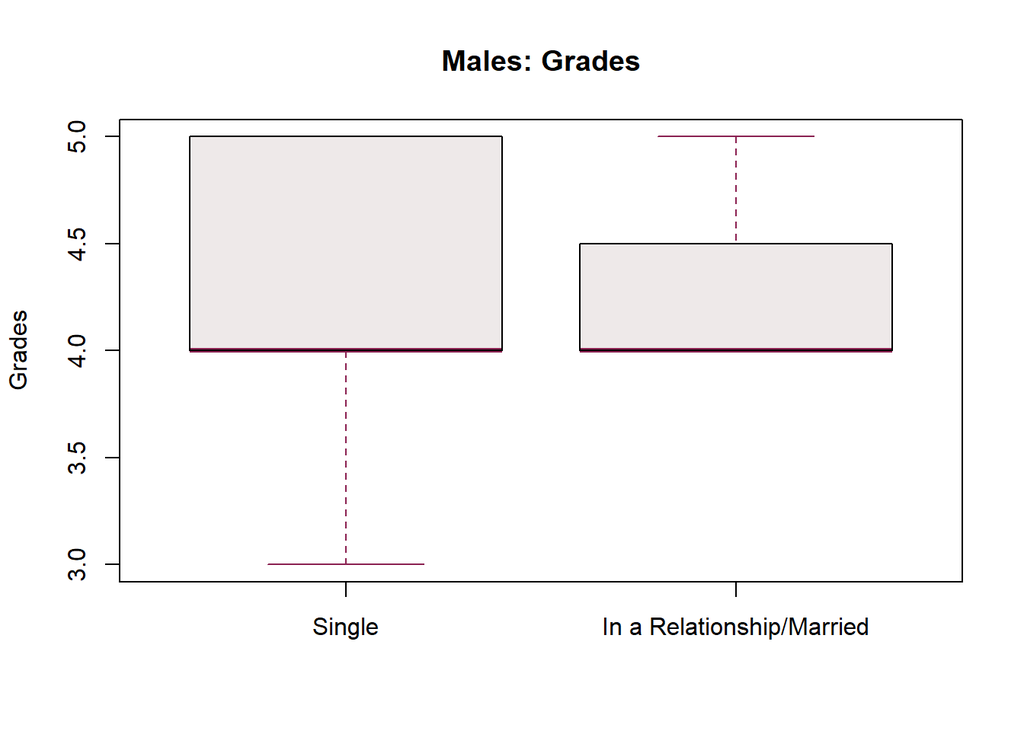

```r
  #Males
boxplot(datamaleS$Grades, datamaleR$Grades, names = c("Single", "In a Relationship/Married"), main = "Males: Grades", ylab = "Grades", whiskcol = "violetred4", staplecol = "violetred4", medcol = "violetred4", col = "snow2", outcol = "violetred4")
```

The above box plot shows the median for grades based off relationship status. We can see that Males who are single tend to have a larger but wider spread in their grades, but also appear to have higher grades then those who are in a relationship/married.

**Wilcoxon Test**

The following test was performed to see if there is an actual difference in the medians of mens grades depending on their relationship status.

```r
wilcoxmale <- wilcox.test(datamaleS$Grades, datamaleR$Grades, mu = 0, alternative = "two.sided", conf.level = .95)
pander(wilcoxmale)
```

Wilcoxon rank sum test with continuity correction: `datamaleS$Grades` and `datamaleR$Grades`

| Test statistic | P value | Alternative hypothesis |
| --- | --- | --- |
| 79.5 | 0.88 | two.sided |

From the Wilcoxon test we can see that there is no significance in the test we ran based off the pValue: $p = .88$. We can conclude that there is insufficient evidence to reject the null hypothesis, meaning the medians of single men vs men in a relationship are the same.

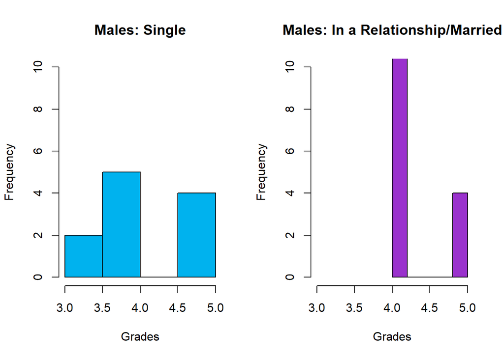

```r
  par(mfrow = c(1,2))

hist(datamaleS$Grades, xlim = c(3, 5), ylim = c(0,10), main = "Males: Single", xlab = "Grades", col = "deepskyblue2")
hist(datamaleR$Grades, xlim = c(3, 5), ylim = c(0,10), main = "Males: In a Relationship/Married", xlab = "Grades", col = "darkorchid3")
```

```r
  par(mfrow = c(1,1))
```

### Data: Female

**Dataset: Female**

The following link contains the female datasets:

Data Table (click to view)

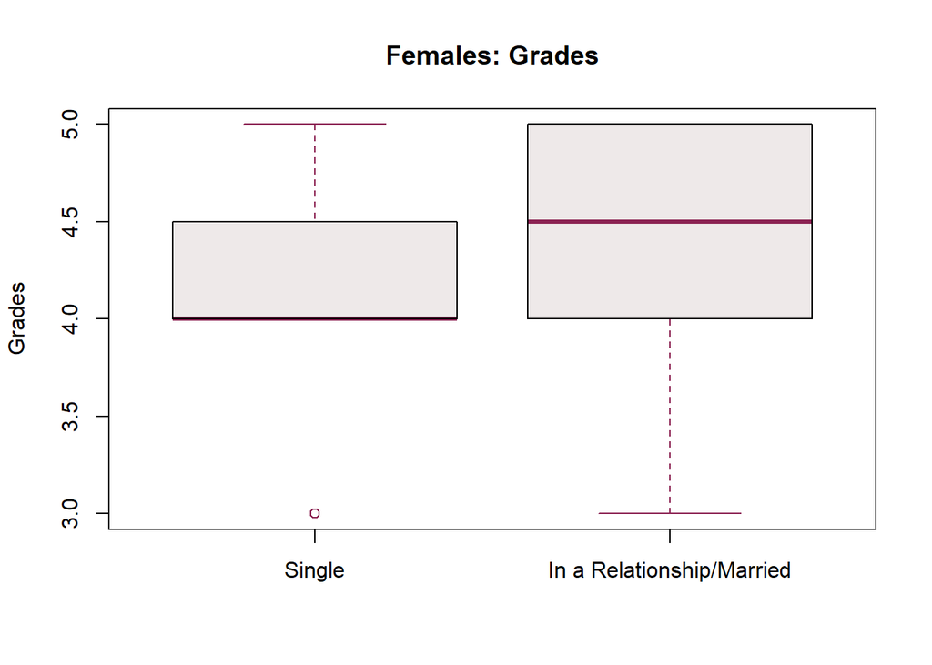

```r
  #Females

boxplot(datafemaleS$Grades, datafemaleR$Grades, names = c("Single", "In a Relationship/Married"), main = "Females: Grades", ylab = "Grades", whiskcol = "violetred4", staplecol = "violetred4", medcol = "violetred4", col = "snow2", outcol = "violetred4")
```

From this boxplot we can see that single females tend to have lower grades than females that are in a relationship.

**Wilcoxon Test**

The following test was performed to see if there is an actual difference in the medians of womans grades depending on their relationship status.

```r
wilcoxfemale <- wilcox.test(datafemaleS$Grades, datafemaleR$Grades, mu = 0, alternative = "two.sided", conf.level = .95)
pander(wilcoxfemale)
```

Wilcoxon rank sum test with continuity correction: `datafemaleS$Grades` and `datafemaleR$Grades`

| Test statistic | P value | Alternative hypothesis |
| --- | --- | --- |
| 129 | 0.09957 | two.sided |

From the Wilcoxon test we can see that the data has a pValue of, $p = 0.09957$, meaning there is insufficient evidence to reject the null hypothesis. Since the null is true there is no difference between the medians for single females and females that are in a relationship/married.

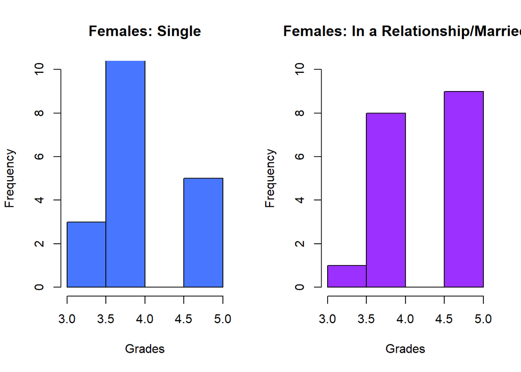

```r
  par(mfrow = c(1,2))

hist(datafemaleS$Grades, xlim = c(3, 5), ylim = c(0,10), main = "Females: Single", xlab = "Grades", col = "royalblue1")
hist(datafemaleR$Grades, xlim = c(3, 5), ylim = c(0,10), main = "Females: In a Relationship/Married", xlab = "Grades", col = "purple1")
```

```r
  par(mfrow = c(1,1))
```

## Combined Groups

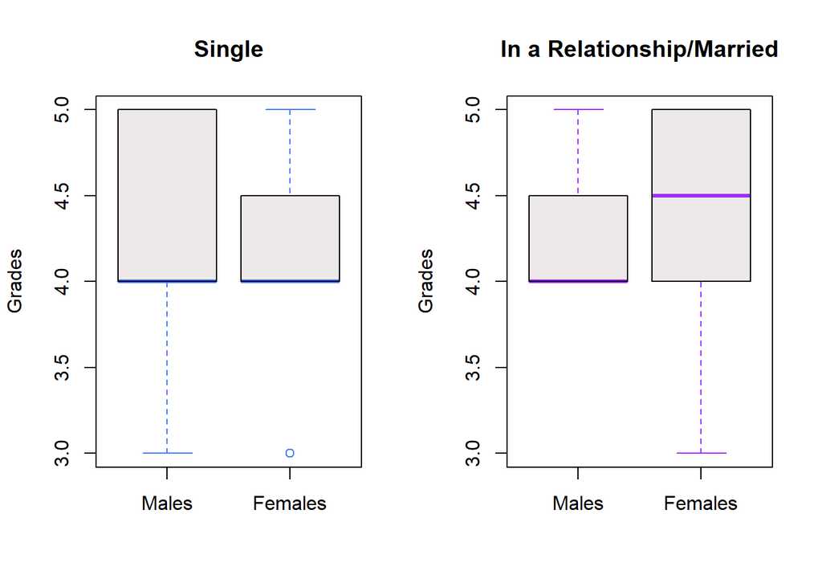

```r
par(mfrow = c(1,2))
boxplot(datamaleS$Grades, datafemaleS$Grades, names = c("Males", "Females"), main = "Single", ylab = "Grades", whiskcol = "royalblue1", staplecol = "royalblue1", medcol = "royalblue1", col = "snow2", outcol = "royalblue1")
boxplot(datamaleR$Grades, datafemaleR$Grades, names = c("Males", "Females"), main = "In a Relationship/Married", ylab = "Grades", whiskcol = "purple1", staplecol = "purple1", medcol = "purple1", col = "snow2", outcol = "purple1")
```

These boxplots are comparing the grades for males and females by status, side by side to help us get a better look at what the data shows us. We can see that for this sample when females are in a relationship/married they have higher grades than those who are single. Also we can see that males who are single have generally higher grades with a larger spread, where as males in a relationship/married have more concentrated grades around 4.0.

## Interpretation

We can conclude from this analysis that there is no significant difference between the medians of each groups, but their appears to be certain trends in the sample that show people in a relationship/married tend to have better grades than those who are single.